# baroth-data-replication-assignment

Brooke Rothamer

2023-12-15

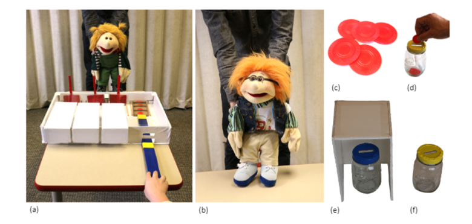

Economic Trust Game Setup (Rosati et al. 2019)

# Overview

I replicated the analyses in Study 1 of Rosati et al. (2019), “Economic trust in young children.”

The general purpose of studies 1-3 was to understand how cooperative trust develops in children using an economic trust game. Overall, the studies demonstrated that children as young as 4 years share more when it is possible for others to reciprocate, and 6-year-olds are better than 4-year-olds at preferring to share with trustworthy partners.

The purpose of Study 1, specifically, was to test whether the youngest participants (age 4) could comprehend the rules of the games used to test economic trust in the later studies. Rosati et al. tested 1) average performance on comprehension tests, 2) average performance in two conditions, and 3) trial-by-trial performance accounting for repeated measures, condition, trial number, and comprehension check scores.

**All the required components of this assignment are met within sections 1) and 3). For ease of grading, only those two sections are necessary to read. I included the other analyses because I wanted to see one study all the way through and try GLMMs.**

# Preparation

Installing packages:

- Install: {tidyverse}, {nortest}, {twosamples}, {distributions3}, {ggpubr}, {lme4}, {Matrix}
- Certain versions of {Matrix} and {lme4} have a compatibility issue. I had to manually delete both packages and reinstall, following the advice of Mikael Jagan at https://stackoverflow.com/questions/77481539/error-in-initializeptr-function-cholmod-factor-ldeta-not-provided-by-pack

```r
> oo <- options(repos = "https://cran.r-project.org/")
> install.packages("Matrix")
> install.packages("lme4")
> options(oo)
```

Load in packages.

```r
> library(tidyverse) #for data organizing
> library(nortest) #for ad.test
> library(twosamples) #for ad_test()
> library(distributions3) #for StudentsT()
```

```r
> library(ggpubr) #for ggbarplot(), ggboxplot(), and ggarrange()
> library(lme4) #for glmer()
> library(Matrix) #for glmer()
```

Load in the original data as formatted by the authors.

```r
> study1 <- read.csv("https://raw.githubusercontent.com/Brothamer/baroth-data-replication-assignment/main/Rosati_etal_Trust_Study1.csv")
> head(study1)
```

```
##          ID Gender Age_group Age_months Trial_absolute Trial_condition
## 1 Child.1.1      M         4       50.5              1               1
## 2 Child.1.1      M         4       50.5              2               2
## 3 Child.1.1      M         4       50.5              3               3
## 4 Child.1.1      M         4       50.5              4               4
## 5 Child.1.1      M         4       50.5              5               1
## 6 Child.1.1      M         4       50.5              6               2
##   Condition Comp_prop_correct Share
## 1    Access               0.5     1
## 2    Access               0.5     1
## 3    Access               0.5     1
## 4    Access               0.5     1
## 5  NoAccess               0.5     1
## 6  NoAccess               0.5     1
```

This data includes results for n=16 four-year-old participants (ID). The independent variable being tested is a binary measure of whether children did or did not share/transfer tokens in a trust game (Share). Each participant was tested in 16 trials (Trial_absolute: 1-16). Half of these trials were in a condition where children had access to the “other side” of the game (Condition = Access), meaning they could receive the materials they successfully transferred. For the other half of the trials, the children could not access the other side of the game (Condition = NoAccess). The data include a variable for the trial number within each condition (Trial_condition). The children also completed 6 comprehension checks during the trials. The data includes the average score of those six comprehension checks (Comp_prop_correct) which is the same value for every trial that child participated in.

# Analyses

## 1) Comprehension Tests

Do 4-year-olds show above chance (50%) performance on comprehension questions? * H0: Performance is not greater than 50%. * HA: Performance is greater than 50%.

Subsetting the data frame to have one entry per subject because each subject only has 1 score for comprehension proportion:

```r
> study1_comprehension <- distinct( #Remove duplicate rows so that each subject has only 1 entry
+                             subset(study1, select = -c(Trial_absolute, Trial_condition, Condition, Share))) #Remove columns not relevant to this specific analysis so that each subject has 16 identical entries
> head(study1_comprehension)
```

```
##          ID Gender Age_group Age_months Comp_prop_correct
## 1 Child.1.1      M         4       50.5              0.50
## 2 Child.1.2      M         4       59.1              1.00
## 3 Child.1.3      M         4       57.3              0.83
## 4 Child.1.4      M         4       53.1              0.50
## 5 Child.1.5      M         4       54.2              1.00
## 6 Child.1.6      M         4       53.3              0.67
```

### 1a) Mean

Mean comprehension proportion correct:

```r
> comprehension_mean <- mean(study1_comprehension$Comp_prop_correct) #take a mean
> comprehension_mean
```

```
## [1] 0.698125
```

Rosati et al. reported mean: 69.8% My mean: 69.8125%

Mean was successfully replicated.

### 1b) Anderson-Darling for Normal Distribution

In the data, n < 30, so it is appropriate to check if the data is normally distributed. Assumedly, Rosati et al. would also have checked for normality before conducting their analyses.

I used an Anderson-Darling Test for normality because it can accept a small sample size of n=16. A Shapiro-Wilk test would have greater power but may be too sensitive for testing the assumptions of a t-test (referring to the module presented by Erin Anderson, Lillian Holden, Amanda Wu, and Emily Yang).

- H0: the sample follows a normal distribution
- HA: the sample does not follow a normal distribution

```r
> ad.test(study1_comprehension$Comp_prop_correct)
```

```
##
##  Anderson-Darling normality test
##
## data:  study1_comprehension$Comp_prop_correct
## A = 0.588, p-value = 0.1061
```

The p-value is not significant at greater than 0.05. Therefore this test fails to reject the null hypothesis that the data is normally distributed. Therefore, we can continue with tests that assume no significant variation from a normal distribution.

### 1c) Confidence Interval

Confidence interval of the mean:

```r
> #upper = mean + (quantile of Student's T distribution)(sample standard error)/(sqrt(n))
> mean(study1_comprehension$Comp_prop_correct) +  quantile(StudentsT(df=15), 0.05 / 2) * sd(study1_comprehension$Comp_prop_correct) / sqrt(16)
```

```
## [1] 0.5523865
```

```r
> #lower= mean - (uantile of Student's T distribution)(sample standard error)/(sqrt(n))
> mean(study1_comprehension$Comp_prop_correct) + quantile(StudentsT(df=15), 1 - 0.05 / 2) * sd(study1_comprehension$Comp_prop_correct) / sqrt(16)
```

```
## [1] 0.8438635
```

```r
> #Or
>
> t.test(study1_comprehension$Comp_prop_correct) #faster to use the t.test() function
```

```
##
##  One Sample t-test
##
## data:  study1_comprehension$Comp_prop_correct
## t = 10.21, df = 15, p-value = 3.798e-08
## alternative hypothesis: true mean is not equal to 0
## 95 percent confidence interval:
##  0.5523865 0.8438635
## sample estimates:
## mean of x
##  0.698125
```

```r
> #But it has to be a two-sided t-test!
```

Confidence interval was successfully replicated.

### 1d) One-Sample, One-Tailed T-test

One sample, one-tailed T test of whether the mean percent correct is greater than chance (50%).

```r
> t.test(study1_comprehension$Comp_prop_correct,
+        mu=0.5, #mean expected by chance
+        alternative = "greater") #testing if the observed mean is greater than the null
```

```
##
##  One Sample t-test
##
## data:  study1_comprehension$Comp_prop_correct
## t = 2.8976, df = 15, p-value = 0.005524
## alternative hypothesis: true mean is greater than 0.5
## 95 percent confidence interval:
##  0.5782596       Inf
## sample estimates:
## mean of x
##  0.698125
```

Rosati et al reported values: t15 = 2.90, p < 0.05 My values: t15 = 2.8976, p = 0.005524

T-test results were successfully replicated.

Note: the confidence interval from this one-tailed t-test is not the reported confidence interval of the mean in general.

## 2) Response to task by condition

Are 4-year-olds more likely to share (opposed to not share) when they have access to the other side of the game (i.e. when they can receive what they shared)? Ho: No difference in probability of sharing between Access and No Access conditions. HA: Probability of sharing is greater in the Access condition than the No Access condition.

### 2a) Means

Aggregate data frame so there is one mean probability of sharing for each subject:

```r
> #apply the function mean to the Share of each group of observations with the same condition and ID
> study1_share <- aggregate(Share ~ ID + Condition, data=study1, FUN = mean)
> head(study1_share)
```

```
##           ID Condition Share
## 1  Child.1.1    Access 1.000
## 2 Child.1.10    Access 1.000
## 3 Child.1.11    Access 0.875
## 4 Child.1.12    Access 0.000
## 5 Child.1.13    Access 1.000
## 6 Child.1.14    Access 0.500
```

Calculate the means of each condition:

```r
> #apply the function mean to the Share of each group of observations with the same condition
> condition_means <- aggregate(Share ~ Condition, data=study1_share, FUN = mean)
> condition_means
```

```
##   Condition     Share
## 1    Access 0.8359375
## 2  NoAccess 0.5625000
```

Rosati et al. reported means: Access = 83.6%, No Access = 56.3% My means: Access = 83.59375%, No Access = 56.25000%

Means were successfully replicated.

### 2b) Confidence intervals of the mean difference

```r
> t.test(Share ~ Condition,
+        data = study1_share,
+        paired = TRUE, #the values in the first set each correspond to a value in the other set
+        alternative = "two.sided") #must be two tailed to get the right confidence interval
```

```
##
##  Paired t-test
##
## data:  Share by Condition
## t = 2.763, df = 15, p-value = 0.0145
## alternative hypothesis: true mean difference is not equal to 0
## 95 percent confidence interval:
##  0.0624982 0.4843768
## sample estimates:
## mean difference
##       0.2734375
```

Rosati et al reported 95% confidence interval: [6.2, 48.4%] My 95% confidence interval: [6.24982, 48.43768%]

Confidence intervals were successfully replicated.

### 2c) Paired-Samples, One-Tailed T-test

```r
> t.test(Share ~ Condition,
+        data = study1_share,
+        paired = TRUE, #the values in the first set each correspond to a value in the other set
+        alternative = "greater") #testing if the observed mean difference is greater than 0
```

```
##
##  Paired t-test
##
## data:  Share by Condition
## t = 2.763, df = 15, p-value = 0.007251
## alternative hypothesis: true mean difference is greater than 0
## 95 percent confidence interval:
##  0.09994655        Inf
## sample estimates:
## mean difference
##       0.2734375
```

```r
>                         #specifically, mean of Access is greater than mean of No Access
```

Rosati et al reported values: t15 = 2.76, p < 0.05 My values: t15 = 2.763, p = 0.007251

Results of the t-test were successfully replicated.

## 3) Figure Replication

The figure I am replicating actually appears in the supplementary materials, not the main publication. This is because I want to replicate a figure relevant to the rest of the analyses I replicated, and no figures from Study 1 are included in the main publication.

Original figure:

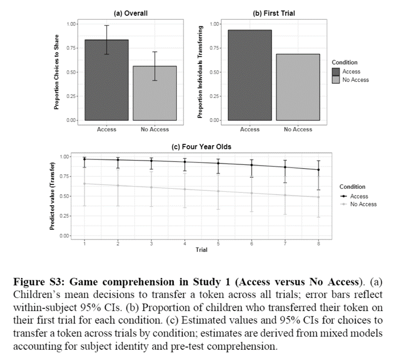

#### (a) Overall plot

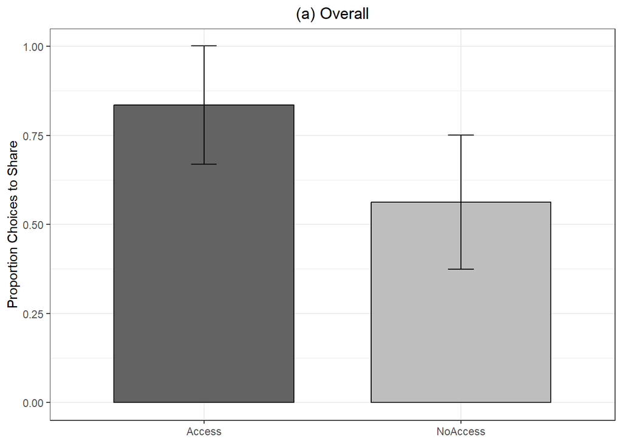

```r
> Overall <- ggbarplot(study1_share, #data
+                      x = "Condition", y = "Share", #x and y variables
+  add = "mean_ci", #add the confidence interval error bar by calculating CI
+  fill = "Condition", palette = c("gray39", "gray"), #fill colors
+           ylab = "Proportion Choices to Share", main = "(a) Overall", #labels
+  ylim = c(0,1)) + #extend y-axis higher
+   theme_bw() + #nice theme
+   theme(plot.title = element_text(hjust=0.5), #center plot title
+         legend.position="none", #remove legend (to be added back later)
+         axis.title.x = element_blank()) #remove x-axis label
> Overall
```

Problem: using multiple methods, I am getting different 95% confidence intervals for the means of each condition in figure S3(a). When I calculate the confidence intervals of the means outside of creating the figure (see below), I get confidence intervals that match my version of the figure: Access 95% CI = [0.670, 1.002], No Access = [0.374, 0.751.]. The figure in Rosati et al appears to have slightly narrower confidence intervals. The authors specified that the 95% confidence intervals are calculated within subject, so I know that is not the problem (though I also calculated the CIs for all trials independently just in case.)

Confidence intervals of Share means for each condition:

```r
> study1_share_access <- study1_share[study1_share$Condition == "Access",] #Subset of the data with Access trials only
> study1_share_noaccess <- study1_share[study1_share$Condition == "NoAccess",] #Subset of the data with NoAccess trials only
> t.test(study1_share_access$Share) #one sample, two-tailed t-test to get confidence intervals
```

```
##
##  One Sample t-test
##
## data:  study1_share_access$Share
## t = 10.718, df = 15, p-value = 1.992e-08
## alternative hypothesis: true mean is not equal to 0
## 95 percent confidence interval:
##  0.6696958 1.0021792
## sample estimates:
## mean of x
## 0.8359375
```

```r
> t.test(study1_share_noaccess$Share) #one sample, two-tailed t-test to get confidence intervals
```

```
##
##  One Sample t-test
##
## data:  study1_share_noaccess$Share
## t = 6.364, df = 15, p-value = 1.272e-05
## alternative hypothesis: true mean is not equal to 0
## 95 percent confidence interval:
##  0.3741047 0.7508953
## sample estimates:
## mean of x
##    0.5625
```

#### (b) First Trial plot

Preparing dataframe for first-trial of each condition barplot:

```r
> study1_firsttrial <- study1[study1$Trial_condition == 1, ] #Subset of the whole study data using only first trials in each condition
> prop_share_firsttrial <- aggregate(Share ~ Condition, data=study1_firsttrial, FUN = mean) #calculate the mean of the first trials for each condition
> prop_share_firsttrial
```

```
##   Condition  Share
## 1    Access 0.9375
## 2  NoAccess 0.6875
```

Plot:

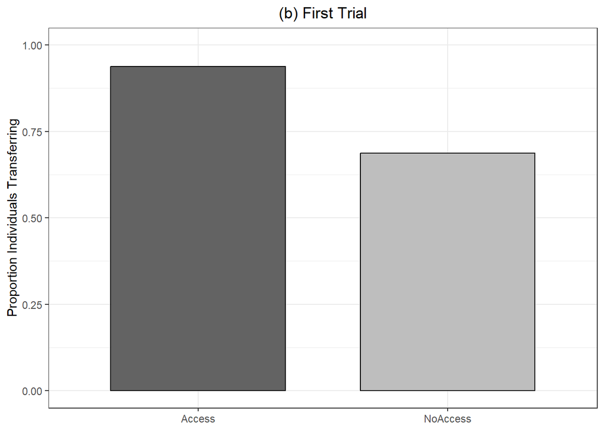

```r
> FirstTrial <- ggbarplot(prop_share_firsttrial, #use  the subsetted data with each subjects first trial in each condition
+                         x = "Condition", y = "Share", #x and y variables
+           fill = "Condition", palette = c("gray39", "gray"), #fill color
+           ylab = "Proportion Individuals Transferring", ylim = c(0,1), main = "(b) First Trial") +
+   theme_bw() + #nice theme
+   theme(plot.title = element_text(hjust=0.5), #center the plot title
+         legend.position="none", #remove legend (to be added back later)
+         axis.title.x = element_blank()) #remove x-axis label
> FirstTrial
```

Arrange the plots with one legend for both of them.

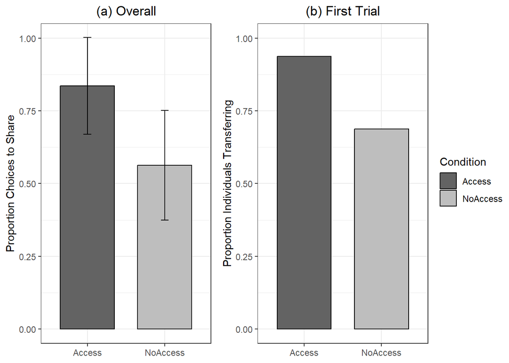

```r
> #Just the first plot again but with the legend included in order to extract the legend
> Overall_withLegend <- ggbarplot(study1_share, x = "Condition", y = "Share",
+  add = "mean_ci", lab.vjust = -1.6, fill = "Condition",
+           palette = c("gray39", "gray"),
+           ylab = "Proportion Choices to Share", main = "(a) Overall", ylim = c(0,1)) +
+   theme_bw() +
+   theme(plot.title = element_text(hjust=0.5), axis.title.x = element_blank())
>
> #a function to extract the legend from a plot (code from https://www.sthda.com/english/wiki/wiki.php?id_contents=7930#grid.arrange-create-and-arrange-multiple-plots)
> get_legend<-function(myggplot){
+   tmp <- ggplot_gtable(ggplot_build(myggplot))
+   leg <- which(sapply(tmp$grobs, function(x) x$name) == "guide-box")
+   legend <- tmp$grobs[[leg]]
+   return(legend)
+ }
>
> #save the legend from the first plot using the function
> legend <- get_legend(Overall_withLegend)
>
> #an arrangement of the two plots and one legend for the two of them
> barplots <- ggarrange(Overall, FirstTrial, legend, ncol = 3, widths=c(2.3, 2.3, 0.8))
> barplots
```

Rosati et al. published figure for comparison:

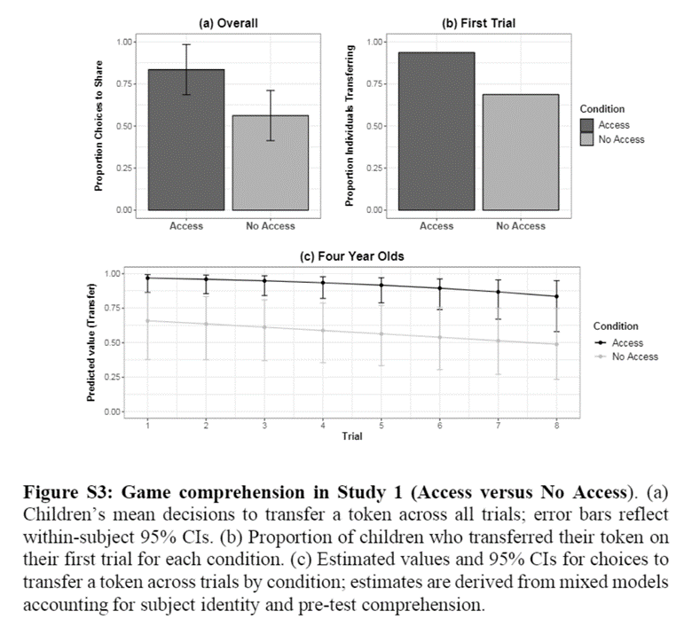

## 4) Trial by Trial GLMMs

Rosati et al used GLMMs fit as “binomial models with a logit link function using maximum likelihood.” They also specified that they used the {lme4} package in R, so I can be confident that I am at least using the same function, glmer().

### 4a) Model Fitting

The base model included random subject intercepts (ID), individual’s average performance on comprehension check questions (Comp_prop_correct), and trial number within condition (Trial_condition). They did not report the parameters of this model, though I suspect that I failed to exactly replicate their method. For a later model, the authors did report the parameters, and while my results are very close, they do not match exactly. My attempt:

```r
> basemod = glmer(data = study1, #glmer() function in {lme4} for GLMMs; specify data
+                 formula = Share ~ #binary response variable
+                   Trial_condition + Comp_prop_correct + #fixed effect predictor variables
+                   (1 | ID), #random intercepts grouped by subject (ID)
+                 family = binomial(link = "logit")) #specifies link function for a binomial model
>
> summary(basemod)
```

```
## Generalized linear mixed model fit by maximum likelihood (Laplace
##   Approximation) [glmerMod]
##  Family: binomial  ( logit )
## Formula: Share ~ Trial_condition + Comp_prop_correct + (1 | ID)
##    Data: study1
##
##      AIC      BIC   logLik deviance df.resid
##    270.5    284.7   -131.2    262.5      252
##
## Scaled residuals:
##     Min      1Q  Median      3Q     Max
## -3.0256 -0.4487  0.3383  0.5691  2.2473
##
## Random effects:
##  Groups Name        Variance Std.Dev.
##  ID     (Intercept) 1.826    1.351
## Number of obs: 256, groups:  ID, 16
##
## Fixed effects:
##                   Estimate Std. Error z value Pr(>|z|)
## (Intercept)         0.1941     1.1305   0.172   0.8637
## Trial_condition    -0.1262     0.0700  -1.803   0.0714 .
## Comp_prop_correct   2.1619     1.4519   1.489   0.1365
## ---
## Signif. codes:  0 '***' 0.001 '**' 0.01 '*' 0.05 '.' 0.1 ' ' 1
##
## Correlation of Fixed Effects:
##             (Intr) Trl_cn
## Trial_cndtn -0.274
## Cmp_prp_crr -0.892 -0.025
```

Rosati et al’s second model added Condition as a main predictor variable. Surprisingly, they did not report the specific parameters of this model despite this one being the best fit. My attempt:

```r
> conditionmod = glmer(data = study1,
+                      formula = Share ~ Trial_condition + Comp_prop_correct +
+                        Condition + #additional response variable
+                        (1 | ID),
+                      family = binomial(link = "logit"))
>
> summary(conditionmod)
```

```
## Generalized linear mixed model fit by maximum likelihood (Laplace
##   Approximation) [glmerMod]
##  Family: binomial  ( logit )
## Formula: Share ~ Trial_condition + Comp_prop_correct + Condition + (1 |
##     ID)
##    Data: study1
##
##      AIC      BIC   logLik deviance df.resid
##    237.9    255.7   -114.0    227.9      251
##
## Scaled residuals:
##     Min      1Q  Median      3Q     Max
## -4.5967 -0.2663  0.2346  0.4374  3.7102
##
## Random effects:
##  Groups Name        Variance Std.Dev.
##  ID     (Intercept) 2.805    1.675
## Number of obs: 256, groups:  ID, 16
##
## Fixed effects:
##                    Estimate Std. Error z value Pr(>|z|)
## (Intercept)        1.326505   0.002229  595.02   <2e-16 ***
## Trial_condition   -0.153125   0.002227  -68.75   <2e-16 ***
## Comp_prop_correct  2.634294   0.002229 1181.67   <2e-16 ***
## ConditionNoAccess -2.158332   0.002230 -967.86   <2e-16 ***
## ---
## Signif. codes:  0 '***' 0.001 '**' 0.01 '*' 0.05 '.' 0.1 ' ' 1
##
## Correlation of Fixed Effects:
##             (Intr) Trl_cn Cmp_p_
## Trial_cndtn 0.000
## Cmp_prp_crr 0.000  0.000
## CndtnNAccss 0.000  0.000  0.000
## optimizer (Nelder_Mead) convergence code: 0 (OK)
## Model failed to converge with max|grad| = 0.031746 (tol = 0.002, component 1)
```

Rosati et al. also tested a third model adding Condition by Trial interaction as an additional main predictor variable. The authors reported the parameters from this model in their supplementary material. My attempt:

```r
> fullmod = glmer(data = study1,
+                 formula = Share ~ Trial_condition + Comp_prop_correct + Condition +
+                   Condition*Trial_condition + #additional response variable with interaction
+                   (1 | ID),
+                 family = binomial(link = "logit"), nAGQ = 1)
>
> summary(fullmod)
```

```
## Generalized linear mixed model fit by maximum likelihood (Laplace
##   Approximation) [glmerMod]
##  Family: binomial  ( logit )
## Formula: Share ~ Trial_condition + Comp_prop_correct + Condition + Condition *
##     Trial_condition + (1 | ID)
##    Data: study1
##
##      AIC      BIC   logLik deviance df.resid
##    239.1    260.3   -113.5    227.1      250
##
## Scaled residuals:
##     Min      1Q  Median      3Q     Max
## -4.1849 -0.2372  0.2264  0.4432  4.1249
##
## Random effects:
##  Groups Name        Variance Std.Dev.
##  ID     (Intercept) 2.851    1.689
## Number of obs: 256, groups:  ID, 16
##
## Fixed effects:
##                                   Estimate Std. Error z value Pr(>|z|)
## (Intercept)                         1.7311     1.4719   1.176  0.23954
## Trial_condition                    -0.2540     0.1390  -1.828  0.06757 .
## Comp_prop_correct                   2.7915     1.7838   1.565  0.11761
## ConditionNoAccess                  -2.9071     0.9384  -3.098  0.00195 **
## Trial_condition:ConditionNoAccess   0.1518     0.1670   0.909  0.36319
## ---
## Signif. codes:  0 '***' 0.001 '**' 0.01 '*' 0.05 '.' 0.1 ' ' 1
##
## Correlation of Fixed Effects:
##             (Intr) Trl_cn Cmp_p_ CndtNA
## Trial_cndtn -0.429
## Cmp_prp_crr -0.792 -0.074
## CndtnNAccss -0.377  0.784 -0.102
## Trl_cnd:CNA  0.354 -0.829  0.059 -0.900
## optimizer (Nelder_Mead) convergence code: 0 (OK)
## unable to evaluate scaled gradient
## Model failed to converge: degenerate  Hessian with 1 negative eigenvalues
```

Rosati et al. published table:

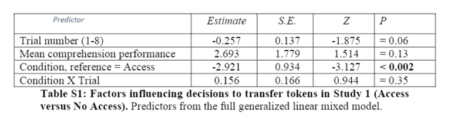

Again, I did not exactly replicate their analyses, but it does appear that I came very close. Therefore, I suspect that my models differ from theirs in some setting. For example, I assumed that Rosati et al left the nAGQ argument set to 1 for a Laplace approximation. However, the authors did not specify the exact model, so it is possible that that assumption was incorrect.

### 4b) Model Comparison

Rosati et al compared the models fits using likelihood ratio tests.

Comparing the condition-only model to the base model show a significantly improved fit. My attempt:

```r
> LRT1<-anova(basemod, conditionmod) #likelihood ratio test using anova() to compare two models
> LRT1
```

```
## Data: study1
## Models:
## basemod: Share ~ Trial_condition + Comp_prop_correct + (1 | ID)
## conditionmod: Share ~ Trial_condition + Comp_prop_correct + Condition + (1 | ID)
##              npar    AIC    BIC  logLik deviance  Chisq Df Pr(>Chisq)
## basemod         4 270.48 284.66 -131.24   262.48
## conditionmod    5 237.94 255.67 -113.97   227.94 34.538  1   4.18e-09 ***
## ---
## Signif. codes:  0 '***' 0.001 '**' 0.01 '*' 0.05 '.' 0.1 ' ' 1
```

Rosati et al reported values: χ2 = 34.54, df = 1, p < 0.0001 My values: χ2 = 34.538, df = 1, p = 4.18e-09

The authors found that comparing the full model (including fixed effects of Condition and Condition x Trial) to the condition-only model did not signficantly improve the fit. My attempt:

```r
> LRT2<-anova(conditionmod, fullmod) #likelihood ratio test using anova() to compare two models
> LRT2
```

```
## Data: study1
## Models:
## conditionmod: Share ~ Trial_condition + Comp_prop_correct + Condition + (1 | ID)
## fullmod: Share ~ Trial_condition + Comp_prop_correct + Condition + Condition * Trial_condition + (1 | ID)
##              npar    AIC    BIC  logLik deviance  Chisq Df Pr(>Chisq)
## conditionmod    5 237.94 255.67 -113.97   227.94
## fullmod         6 239.07 260.34 -113.53   227.07 0.8753  1     0.3495
```

Rosati et al reported values: χ2 = 0.88, df = 1, p = 0.34, n.s. My values: χ2 = 0.8753, df = 1, p = 0.3495, n.s.

Despite having some differences in the third model, the results of my tests were similar to Rosati et al’s. They would appear exact except the p-value in my second comparison is slightly higher, hinting that the models were not a match to begin with. While this is most likely an error on my part, Rosati et al could have improved the ease of replication of their analyses by including the formulas and specifications of the models they tested and the outcomes of each model as they did for their third model in the supplementary materials.